# The University of Tennessee-Knoxville (Knoxville, TN)

### General information

- Public, 4-year or above
- Doctoral Universities: Very High Research Activity
- **California considers the state this institution is in to have one or more anti-LGBTQ+ laws.** See more [here](https://oag.ca.gov/ab1887)
- Undergraduate enrollment is 23,290 (includes all undergrads; some of the numbers below are based on first time, full time, degree seeking students only).
- See mission at https://top25.utk.edu/mission-vision/
- 79% of applicants are admitted
- 31% of admitted applicants choose to enroll
- 87% of students stay after their first year
- 72% of students graduate
- The student to all faculty ratio is 17:1
- The student to tenured or tenure-track faculty ratio is 63:1
- Students are not required to be vaccinated against COVID-19
- Employees are not required to be vaccinated against COVID-19
- This college is located in a midsize city
- The closest mass transit is a 0 minute walk away
- As of July, 2022, the state this institution is in had abortion restrictions categorized “very restrictive” by the [Guttmacher Institute](https://states.guttmacher.org/policies/), though this may change.
- Athletic conference: Southeastern Conference

# Details

## Tables

### Degrees awarded each year

| Degree | Number |
| --- | --- |
| Associate | 0 |
| Bachelor | 5060 |
| Master | 1598 |
| Doctor | 620 |

### Diversity among the faculty

Two things to note here are diversity overall as well as the distribution tenure, tenure track, and non tenure track faculty. There are two main tracks in academia: faculty who are given short term contracts (and often a high teaching load and lower pay) and faculty who are essentially on probation (for 3-6 years, typically) and then are given tenure or fired. For more about tenure, see [here](https://www.aaup.org/issues/tenure). Tenure is a way of protecting academic freedom (tenured faculty can be fired for misconduct or if a program is closed, but not for their research or speech); the fact that it is often more stable also helps ensure that faculty will be at an institution long term to serve as mentors, letter writers, etc. Having more non-tenure-track faculty can save money (they are often paid less, and teach more), reduce public dissent (they can be fired for taking a stand unpopular with their employer), and reduce research or other creative output, including mentoring in these areas (teaching loads are often higher, and research/creative output expectations lower, for faculty in non-tenure-track positions at large universities).

|  | Tenured (count) | Tenure-track (count) | Non-tenure-track (count) | Tenured (percent) | Tenure-track (percent) | Non-tenure-track (percent) |
| --- | --- | --- | --- | --- | --- | --- |
| Grand total men | 553 | 160 | 179 | 34% | 9.8% | 11% |
| Grand total women | 290 | 129 | 314 | 17.8% | 7.9% | 19.3% |
| American Indian or Alaska Native men | 2 | 0 | 0 | 0.1% | 0% | 0% |
| American Indian or Alaska Native women | 0 | 0 | 0 | 0% | 0% | 0% |
| Asian men | 78 | 15 | 9 | 4.8% | 0.9% | 0.6% |
| Asian women | 26 | 7 | 11 | 1.6% | 0.4% | 0.7% |
| Black or African American men | 14 | 10 | 4 | 0.9% | 0.6% | 0.2% |
| Black or African American women | 11 | 11 | 11 | 0.7% | 0.7% | 0.7% |
| Hispanic or Latino men | 21 | 8 | 6 | 1.3% | 0.5% | 0.4% |
| Hispanic or Latino women | 7 | 9 | 14 | 0.4% | 0.6% | 0.9% |
| Native Hawaiian or Other Pacific Islander men | 0 | 0 | 0 | 0% | 0% | 0% |
| Native Hawaiian or Other Pacific Islander women | 0 | 0 | 0 | 0% | 0% | 0% |
| White men | 435 | 98 | 147 | 26.8% | 6% | 9% |
| White women | 240 | 89 | 268 | 14.8% | 5.5% | 16.5% |
| Two or more races men | 1 | 2 | 0 | 0.1% | 0.1% | 0% |
| Two or more races women | 5 | 3 | 2 | 0.3% | 0.2% | 0.1% |
| Race/ethnicity unknown men | 0 | 0 | 0 | 0% | 0% | 0% |
| Race/ethnicity unknown women | 0 | 0 | 1 | 0% | 0% | 0.1% |
| Nonresident alien men | 2 | 27 | 13 | 0.1% | 1.7% | 0.8% |
| Nonresident alien women | 1 | 10 | 7 | 0.1% | 0.6% | 0.4% |

### Diversity among the students

|  | Undergrad (count) | Grad student (count) | Undergrads (percent) | Grad students (percent) |
| --- | --- | --- | --- | --- |
| Grand total men | 10679 | 1653 | 48.5% | 43.3% |
| Grand total women | 11339 | 2163 | 51.5% | 56.7% |
| American Indian or Alaska Native men | 19 | 4 | 0.1% | 0.1% |
| American Indian or Alaska Native women | 18 | 5 | 0.1% | 0.1% |
| Asian men | 475 | 36 | 2.2% | 0.9% |
| Asian women | 426 | 42 | 1.9% | 1.1% |
| Black or African American men | 602 | 77 | 2.7% | 2% |
| Black or African American women | 685 | 137 | 3.1% | 3.6% |
| Hispanic men | 473 | 64 | 2.1% | 1.7% |
| Hispanic women | 541 | 108 | 2.5% | 2.8% |
| Native Hawaiian or Other Pacific Islander men | 11 | 0 | 0% | 0% |
| Native Hawaiian or Other Pacific Islander women | 11 | 1 | 0% | 0% |
| White men | 8356 | 1152 | 38% | 30.2% |
| White women | 8900 | 1621 | 40.4% | 42.5% |
| Two or more races men | 376 | 42 | 1.7% | 1.1% |
| Two or more races women | 469 | 56 | 2.1% | 1.5% |
| Race/ethnicity unknown men | 196 | 37 | 0.9% | 1% |
| Race/ethnicity unknown women | 167 | 41 | 0.8% | 1.1% |
| Nonresident alien men | 171 | 241 | 0.8% | 6.3% |
| Nonresident alien women | 122 | 152 | 0.6% | 4% |

### US student origins

First time degree seeking undergrads

**There are no available data on states of origin**

### Library resources

[output not shown]

## Figures

### Student to faculty ratio compared to similar institutions:

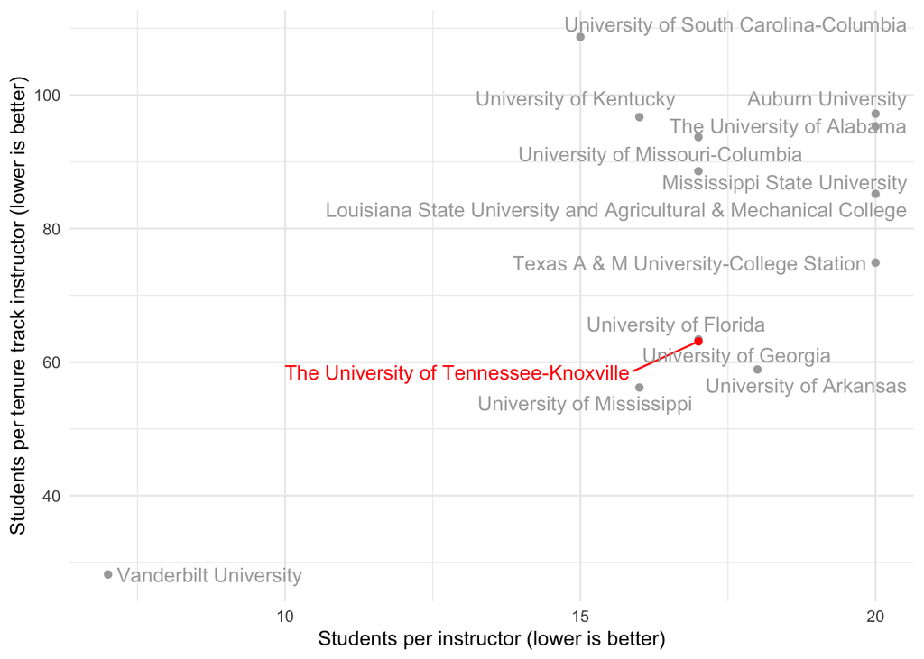